| title: “Statistical Foundations for Data Science - Assignment3” |
| --- |
| author: “Travis Deason” |
| date: “Sept, 17th 2017” |
| output: html_document |

# Live session unit 02 assignment

Calculation Questions (using R) - Use R to calculate the following: NOTE: Submit a word file with the R codes in text format and its screenshot that shows the result.

```r
rm( list = ls()); cat("\014")  # Clear environment
```

#### 1. In the United States, it is illegal to discriminate against people based on various attributes. One example is age. An active lawsuit, filed August 30, 2011, in the Los Angeles District Office is a case against the American Samoa Government for systematic age discrimination by preferentially firing older workers. Though the data and details are currently sealed, suppose that a random sample of the ages of fired and not fired people in the American Samoa Government are listed below:

Fired 34 37 37 38 41 42 43 44 44 45 45 45 46 48 49 53 53 54 54 55 56 Not fired 27 33 36 37 38 38 39 42 42 43 43 44 44 44 45 45 45 45 46 46 47 47 48 48 49 49 51 51 52 54

**a** Check the assumptions (with SAS) of the two sample t-test with respect to this data. Address each assumption individually as we did in the videos and live session and make sure and copy and paste the histograms, qq-plots or any other graphic you use (boxplots, etc.) to defend your written explanation. Do you feel that the t-test is appropriate?

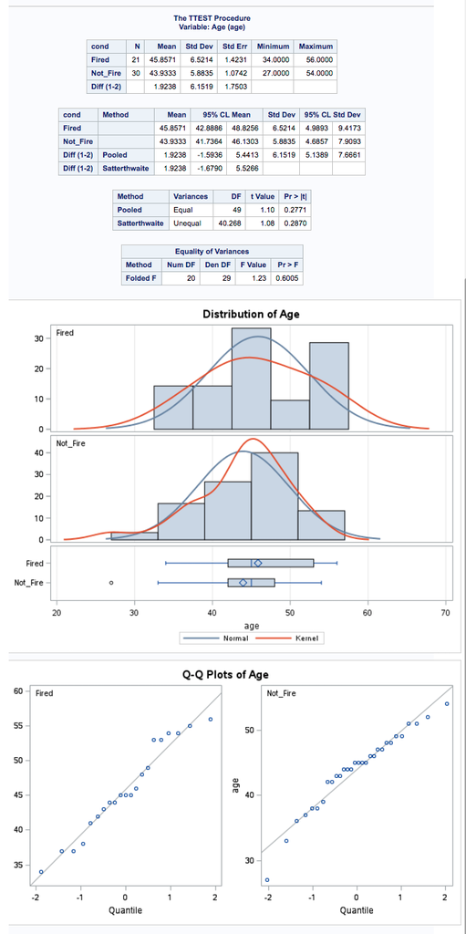

SAS output

**b** Check the assumptions with R and compare them with the plots from SAS.

```r
Fired = c(34,37,37,38,41,42,43,44,44,45,45,45,46,48,49,53,53,54,54,55,56)
Not_Fired = c(27,33,36,37,38,38,39,42,42,43,43,44,44,44,45,45,45,45,46,46,47,47,48,48,49,49,51,51,52,54)

print("Fired")
```

```
## [1] "Fired"
```

```r
length(Fired)
```

```
## [1] 21
```

```r
summary(Fired)
```

```
##    Min. 1st Qu.  Median    Mean 3rd Qu.    Max.
##   34.00   42.00   45.00   45.86   53.00   56.00
```

```r
print('Not Fired')
```

```
## [1] "Not Fired"
```

```r
length(Not_Fired)
```

```
## [1] 30
```

```r
summary(Not_Fired)
```

```
##    Min. 1st Qu.  Median    Mean 3rd Qu.    Max.
##   27.00   42.00   45.00   43.93   47.75   54.00
```

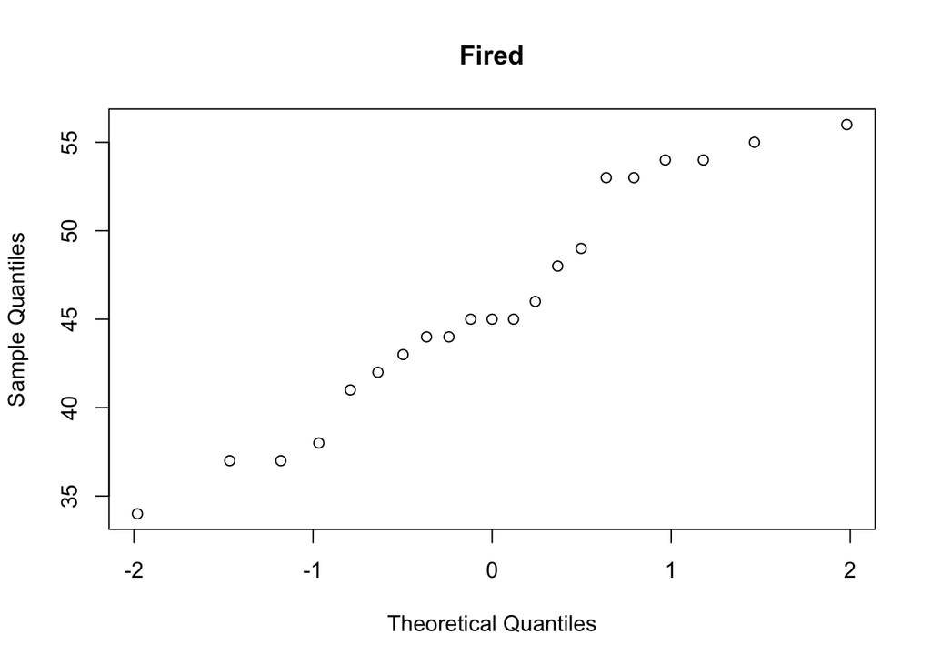

```r
qqnorm(Fired, main='Fired')
```

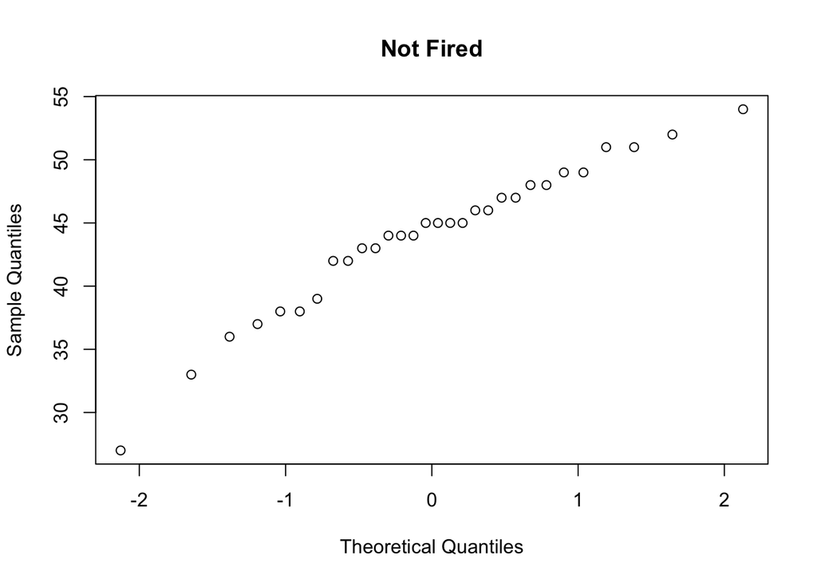

```r
qqnorm(Not_Fired, main='Not Fired')
```

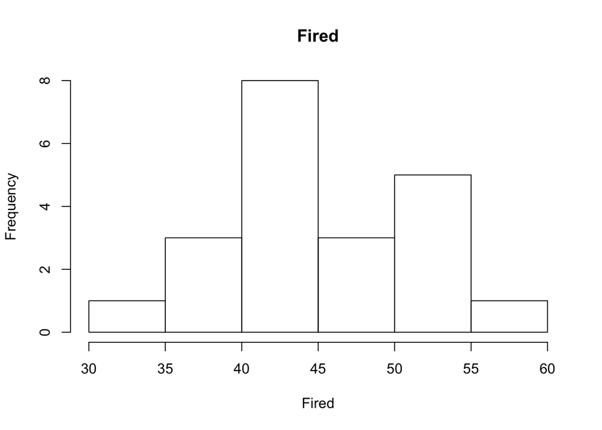

```r
hist(Fired, main='Fired')
```

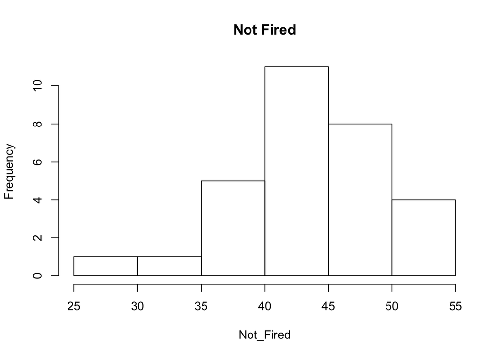

```r
hist(Not_Fired, main='Not Fired')
```

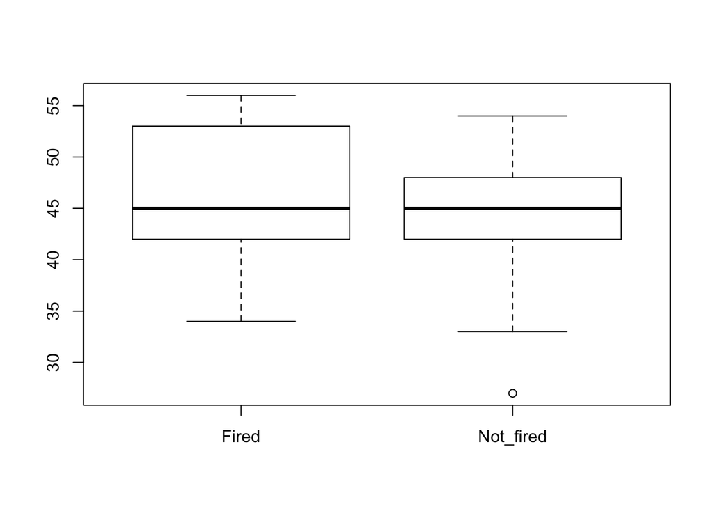

```r
boxplot(Fired, Not_Fired, names=c('Fired', 'Not_fired'))
```

- Review of the data in R shows much the same thing as the review in SAS. The data resembles a normal distribution, the samples have similar variances, and there are enough datapoints to run a t-test.

**c**. Now perform a complete analysis of the data. You may use either the permutation test from HW 1 or the t-test from HW 2 (copy and paste) depending on your answer to part a. In your analysis be sure and cover all the steps of a complete analysis. 1. State the problem. 2. Address the assumptions of t-test (from part a). 3. Perform the t-test if it is appropriate and a permutation test if it is not (judging from your analysis of the assumptions). 4. Provide a conclusion including the p-value and a confidence interval. 5. Provide the scope of inference. (Steps 3-5 are from your previous HW; you are just putting everything together.) NOTE: THIS QUESTION SHOULD BE EASY AS YOU ARE SIMPLY FORMATTING YOUR RESULTS FROM EARLIER IN THE ABOVE FORM. IT REALLY JUST EQUATES TO ADDING A STATEMENT OF THE PROBLEM AND ADDRESSING THE ASSUMPTIONS (1 or 2 above.) (You can basically copy and paste the rest. We are simply putting everything together to make a complete report.)

```r
t.test(Fired, Not_Fired, c('two.sided', 'less', 'greater'), )
```

```
##
##  Welch Two Sample t-test
##
## data:  Fired and Not_Fired
## t = 1.079, df = 40.268, p-value = 0.287
## alternative hypothesis: true difference in means is not equal to 0
## 95 percent confidence interval:
##  -1.678993  5.526612
## sample estimates:
## mean of x mean of y
##  45.85714  43.93333
```

#### 2. In the last homework it was mentioned that a Business Stats class here at SMU was polled and students were asked them how much money (cash) they had in their pockets at that very moment. The idea was to see if there was evidence that those in charge of the vending machines should include the expensive bill / coin acceptor or if it should just have the credit card reader. However, a professor from Seattle University polled her class with the same question. Below are the results of the polls.

SMU 34, 1200, 23, 50, 60, 50, 0, 0, 30, 89, 0, 300, 400, 20, 10, 0 Seattle U 20, 10, 5, 0, 30, 50, 0, 100, 110, 0, 40, 10, 3, 0

**a**. Check the assumptions (with SAS or R) of the two sample t-test with respect to this data. Address each assumption individually as we did in the videos and live session and make sure to copy and paste the histograms, qq-plots or any other graphic you use (boxplots, etc.) to defend your written explanation. Do you feel that the t-test is appropriate?

```r
smu = c(
34, 1200, 23, 50, 60, 50, 0, 0, 30, 89, 0, 300, 400, 20, 10, 0)
sea = c(
20, 10, 5, 0, 30, 50, 0, 100, 110, 0, 40, 10, 3, 0)

print("smu")
```

```
## [1] "smu"
```

```r
length(smu)
```

```
## [1] 16
```

```r
summary(smu)
```

```
##    Min. 1st Qu.  Median    Mean 3rd Qu.    Max.
##    0.00    7.50   32.00  141.62   67.25 1200.00
```

```r
print('sea')
```

```
## [1] "sea"
```

```r
length(sea)
```

```
## [1] 14
```

```r
summary(sea)
```

```
##    Min. 1st Qu.  Median    Mean 3rd Qu.    Max.
##    0.00    0.75   10.00   27.00   37.50  110.00
```

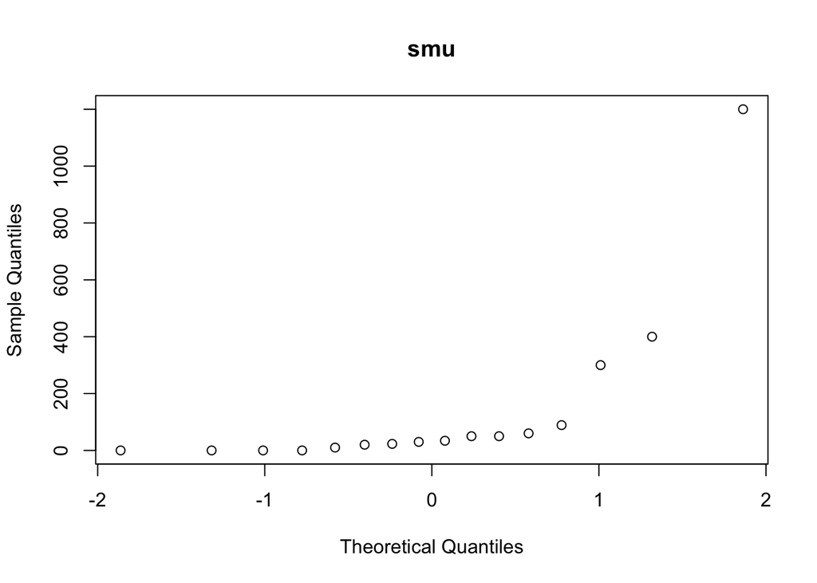

```r
qqnorm(smu, main='smu')
```

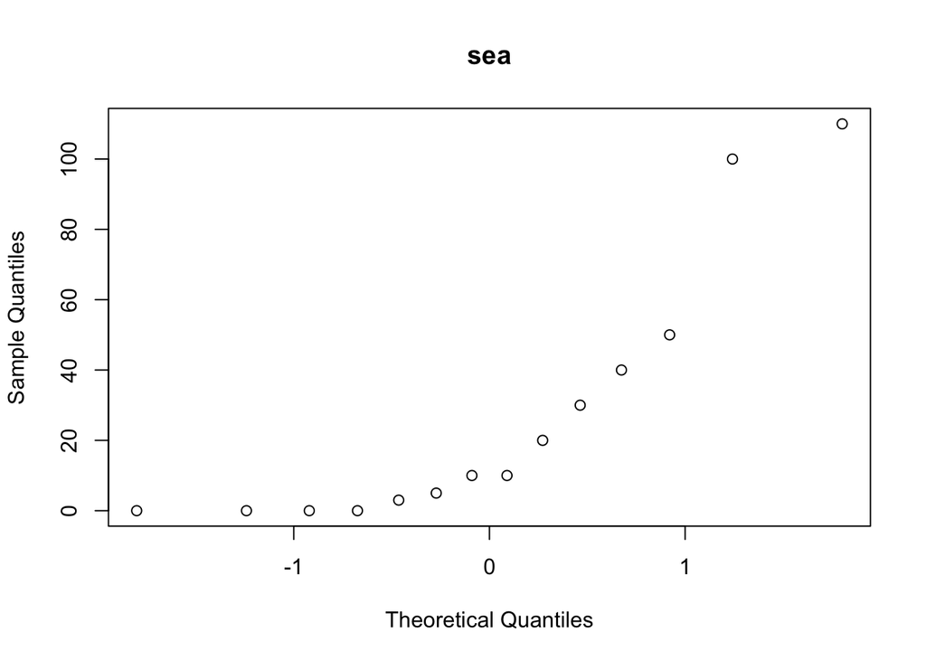

```r
qqnorm(sea, main='sea')
```

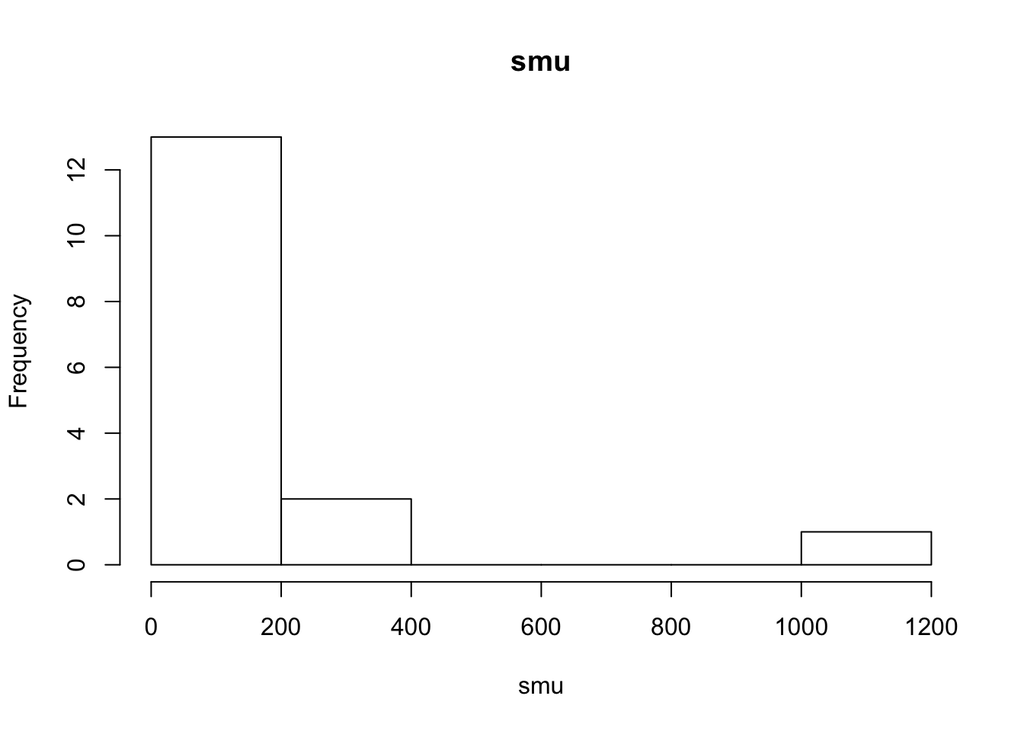

```r
hist(smu, main='smu')
```

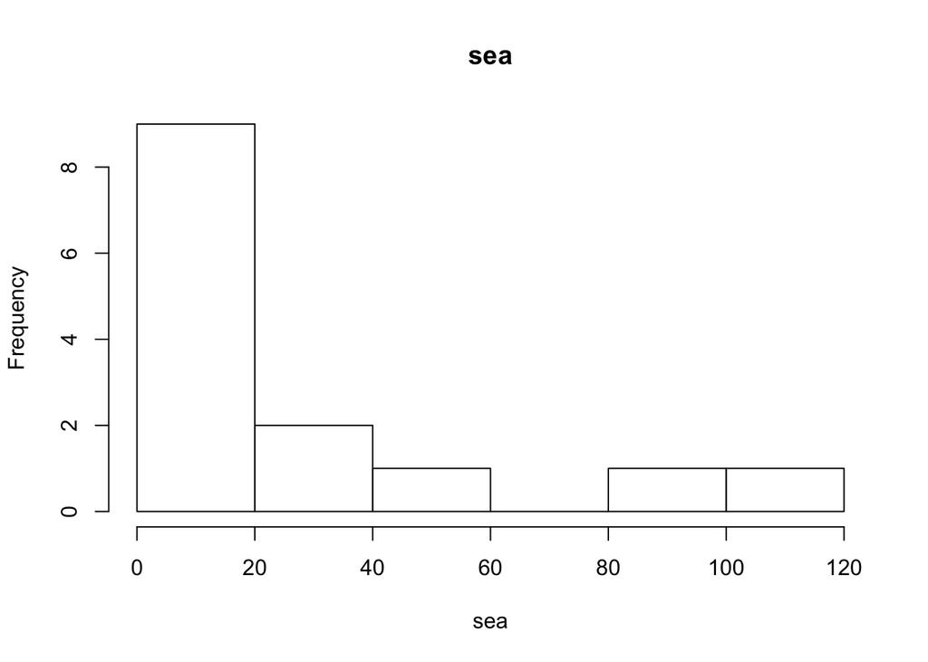

```r
hist(sea, main='sea')
```

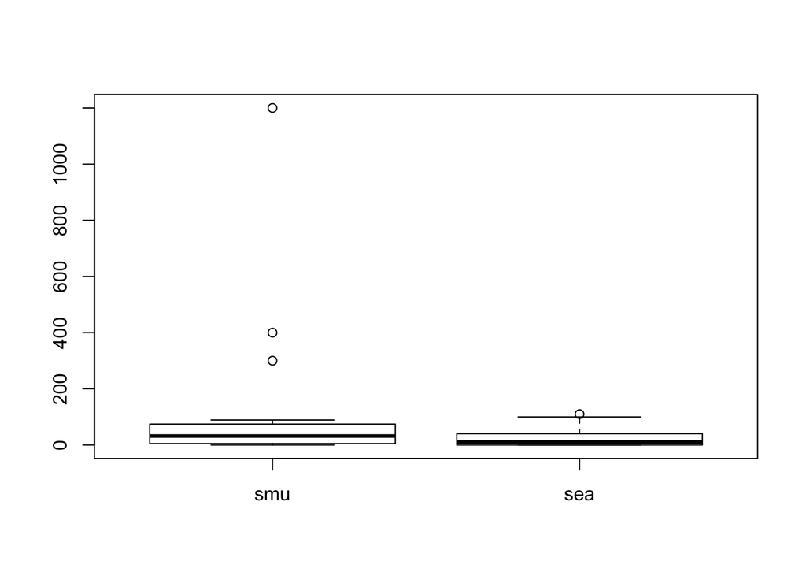

```r
boxplot(smu, sea, names=c('smu', 'sea'))
```

- The data in the change study is not normally distributed, the sample variance is very diffirent, and the sample size is not large enough to overcome these issues. This is not a good cantidate for a two sample t-test prior to transformation.

```r
smu = c(
34, 1200, 23, 50, 60, 50, 0, 0, 30, 89, 0, 300, 400, 20, 10, 0)
sea = c(
20, 10, 5, 0, 30, 50, 0, 100, 110, 0, 40, 10, 3, 0)

sea[sea == 0] = 1
smu[smu == 0] = 1

smu = log(smu)
sea= log(sea)

print("smu")
```

```
## [1] "smu"
```

```r
length(smu)
```

```
## [1] 16
```

```r
sd(smu)
```

```
## [1] 2.230103
```

```r
summary(smu)
```

```
##    Min. 1st Qu.  Median    Mean 3rd Qu.    Max.
##   0.000   1.727   3.464   3.160   4.193   7.090
```

```r
print('sea')
```

```
## [1] "sea"
```

```r
length(sea)
```

```
## [1] 14
```

```r
sd(sea)
```

```
## [1] 1.75853
```

```r
summary(sea)
```

```
##    Min. 1st Qu.  Median    Mean 3rd Qu.    Max.
##  0.0000  0.2747  2.3026  2.1869  3.6170  4.7005
```

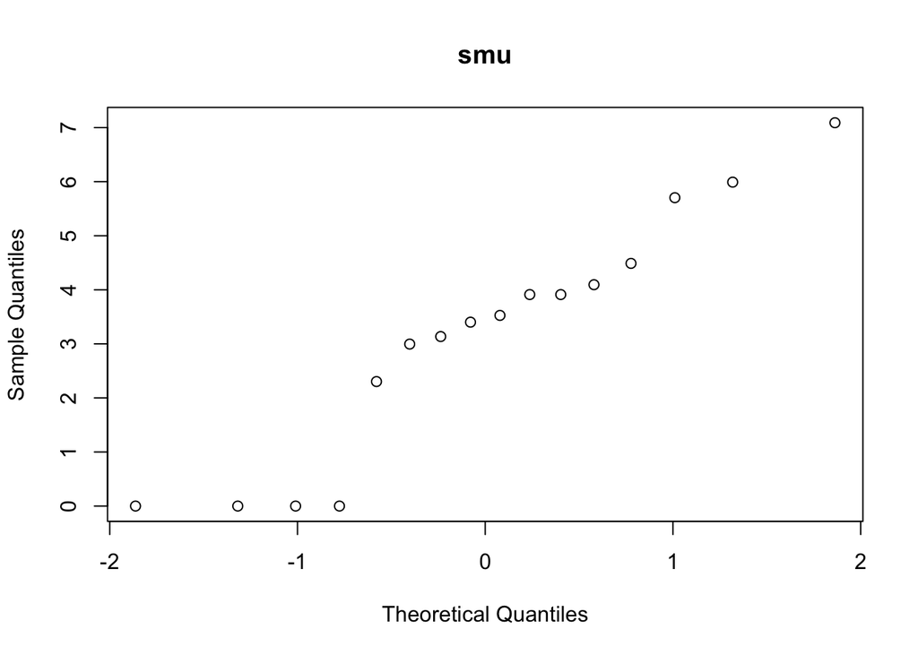

```r
qqnorm(smu, main='smu')
```

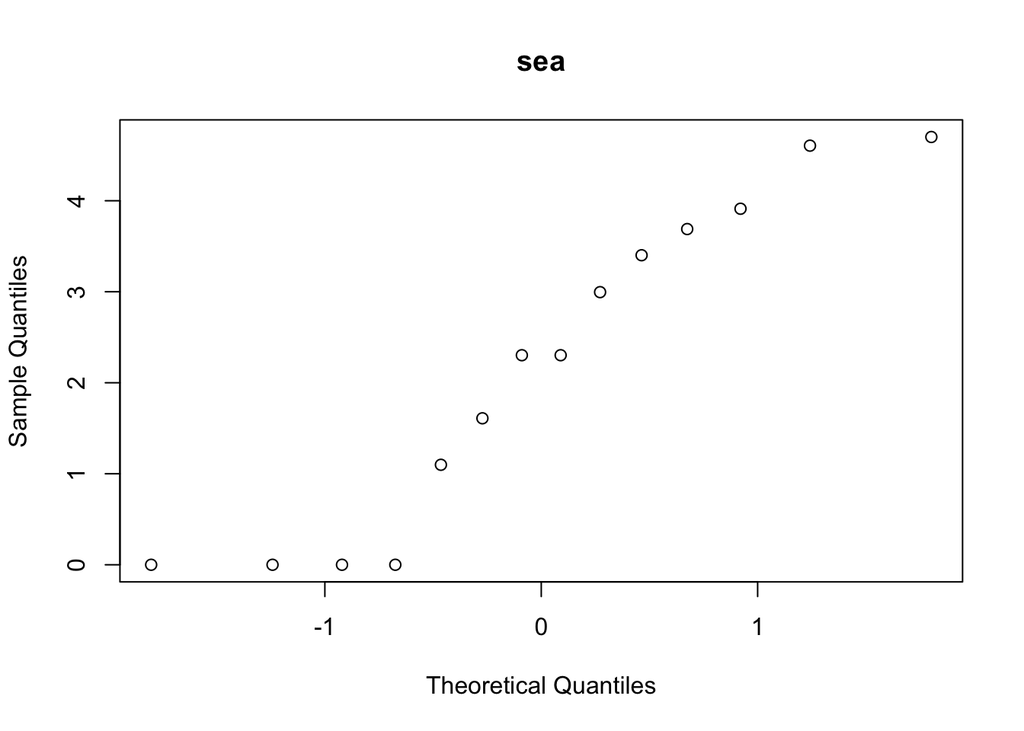

```r
qqnorm(sea, main='sea')
```

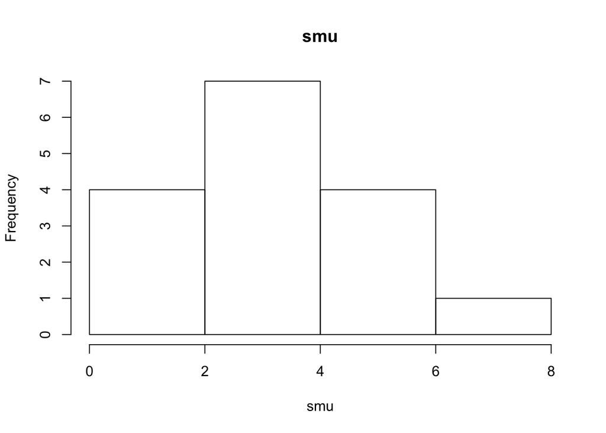

```r
hist(smu, main='smu')
```

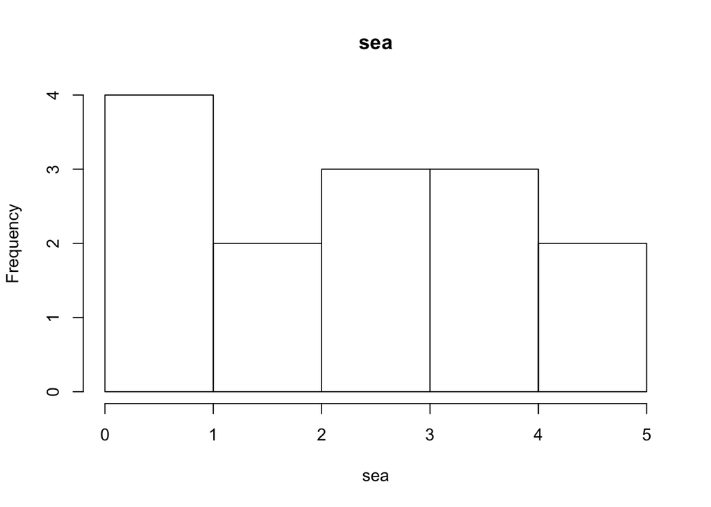

```r
hist(sea, main='sea')
```

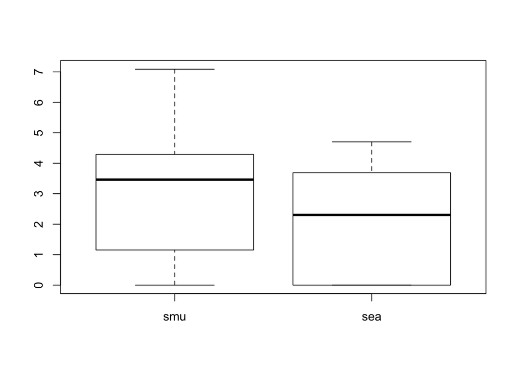

```r
boxplot(smu, sea, names=c('smu', 'sea'))
```

- By performing a log transformation on the data both datasets approximate normal, the variance is now similar, and performing a t-test on the sample is now valid note: Students who had no pocket change had the value of 1 cent substituted to prevent numerical errors. This is an approxmiation.

**b**. Now perform a complete analysis of the data. You may use either the permutation test from HW 1 or the t-test from HW 2 (copy and paste) depending on your answer to part a. In your analysis, be sure to cover all the steps of a complete analysis. 1. State the problem. 2. Address the assumptions of t-test (from part a) 3. Perform the t-test if it is appropriate and a permutation test if it is not (judging from your analysis of the assumptions.) 4. Provide a conclusion including the p-value and a confidence interval. 5. Provide the scope of inference. (Steps 3-5 are from your previous HW; you are just putting everything together.) NOTE: AGAIN, THIS QUESTION SHOULD BE EASY AS YOU ARE SIMPLY FORMATTING YOUR RESULTS FROM EARLIER IN THE ABOVE FORM. IT REALLY JUST EQUATES TO ADDING A STATEMENT OF THE PROBLEM AND ADDRESSING THE ASSUMPTIONS (1 or 2 above.) (You can basically copy and paste the rest. We are simply putting everything together to make a complete report.)

```r
t.test(smu, sea, c('two.sided', 'less', 'greater'))
```

```
##
##  Welch Two Sample t-test
##
## data:  smu and sea
## t = 1.3339, df = 27.734, p-value = 0.1931
## alternative hypothesis: true difference in means is not equal to 0
## 95 percent confidence interval:
##  -0.5216308  2.4670311
## sample estimates:
## mean of x mean of y
##  3.159608  2.186907
```

```r
#ci = exp(c(-0.5216308,  2.4670311))
stdv = sd(c(smu, sea))
ci = exp(c(-0.5216308,  2.4670311)+stdv*2 / 2)
print('mean pocket change')
```

```
## [1] "mean pocket change"
```

```r
exp(c(3.159608,  2.186907)+stdv*2 / 2)
```

```
## [1] 183.01311  69.19003
```

```r
print('Confidence Interval')
```

```
## [1] "Confidence Interval"
```

```r
print(ci)
```

```
## [1]  4.61042 91.55875
```

**c**. Note the potential outlier in the SMU data set. Recheck the assumptions in SAS or R without the outlier. Does this change your decision about the appropriateness of the t tools? Compare the p-value from the t-test with and without the outlier. Based on your analysis so far, what should we do with this outlier? Consult the outlier flowchart in Section 3.4.

```r
smu = c(
34, 23, 50, 60, 50, 0, 0, 30, 89, 0, 300, 400, 20, 10, 0)
sea = c(
20, 10, 5, 0, 30, 50, 0, 100, 110, 0, 40, 10, 3, 0)

sea[sea == 0] = 1
smu[smu == 0] = 1

smu = log(smu)
sea= log(sea)

print("smu")
```

```
## [1] "smu"
```

```r
length(smu)
```

```
## [1] 15
```

```r
sd(smu)
```

```
## [1] 2.037539
```

```r
summary(smu)
```

```
##    Min. 1st Qu.  Median    Mean 3rd Qu.    Max.
##   0.000   1.151   3.401   2.898   4.003   5.991
```

```r
print('sea')
```

```
## [1] "sea"
```

```r
length(sea)
```

```
## [1] 14
```

```r
sd(sea)
```

```
## [1] 1.75853
```

```r
summary(sea)
```

```
##    Min. 1st Qu.  Median    Mean 3rd Qu.    Max.
##  0.0000  0.2747  2.3026  2.1869  3.6170  4.7005
```

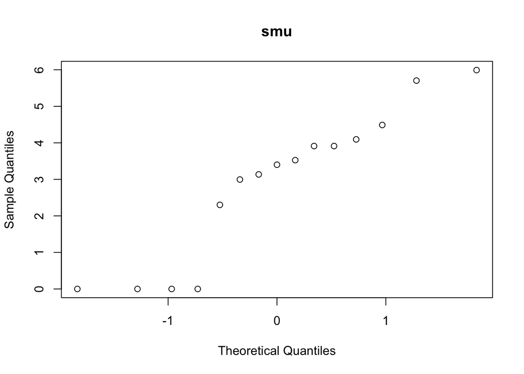

```r
qqnorm(smu, main='smu')
```

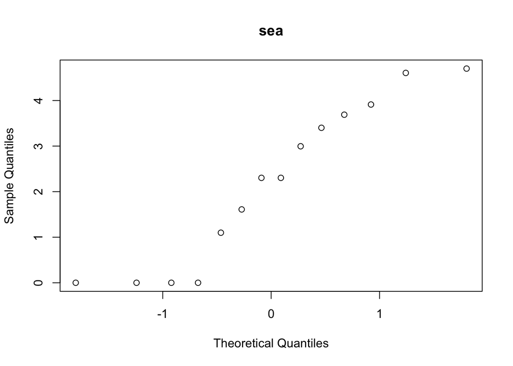

```r
qqnorm(sea, main='sea')
```

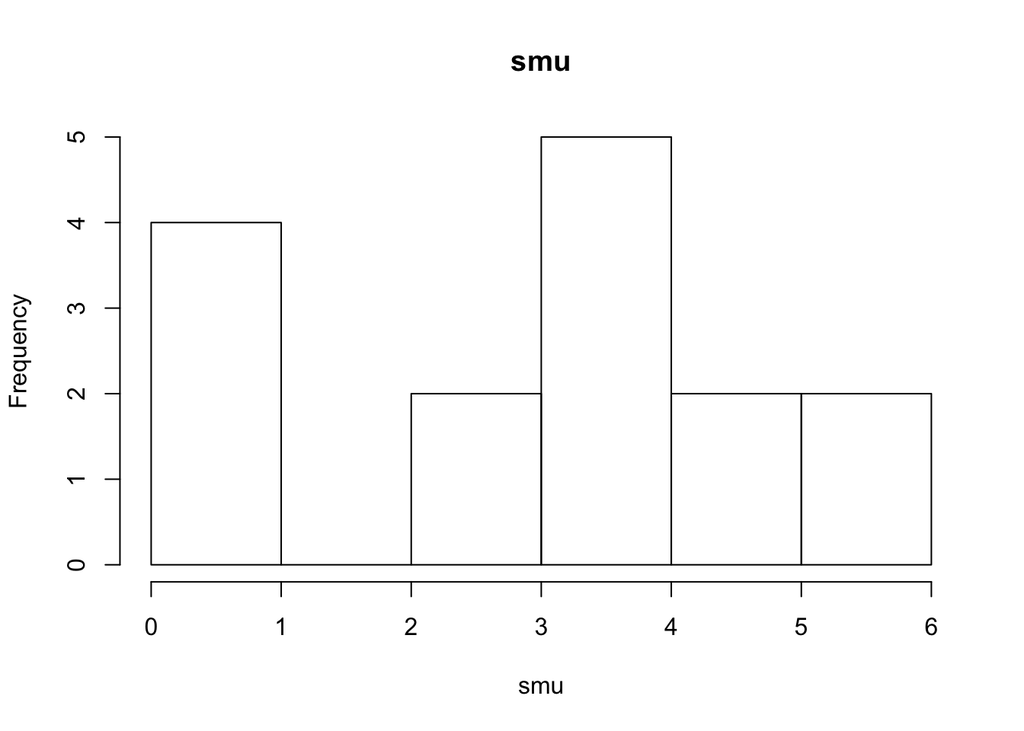

```r
hist(smu, main='smu')
```

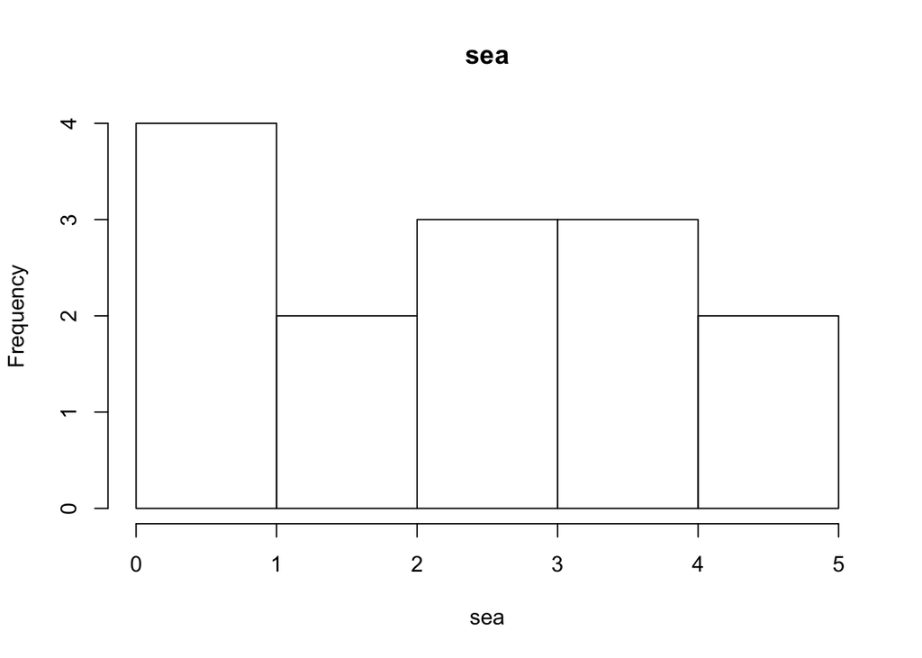

```r
hist(sea, main='sea')
```

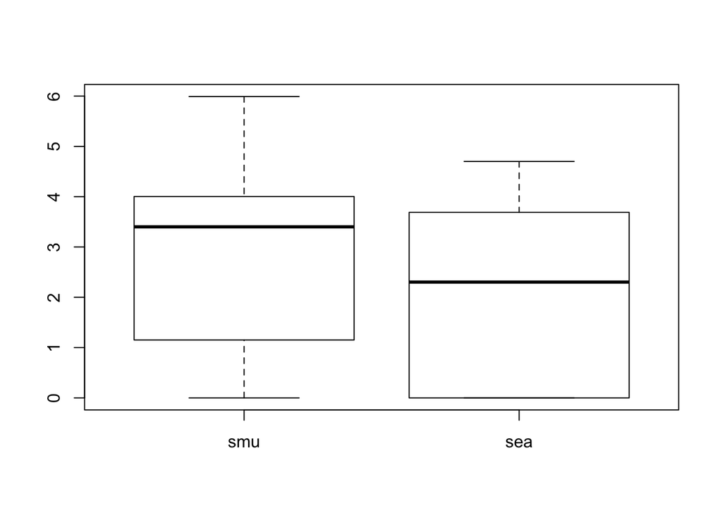

```r
boxplot(smu, sea, names=c('smu', 'sea'))
```

```r
t.test(smu, sea, c('two.sided', 'less', 'greater'))
```

```
##
##  Welch Two Sample t-test
##
## data:  smu and sea
## t = 1.0074, df = 26.848, p-value = 0.3227
## alternative hypothesis: true difference in means is not equal to 0
## 95 percent confidence interval:
##  -0.7371778  2.1585155
## sample estimates:
## mean of x mean of y
##  2.897576  2.186907
```

```r
stdv = sd(c(smu, sea))
ci = exp(c(-0.5216308,  2.4670311)+stdv*2 / 2)
print('mean pocket change')
```

```
## [1] "mean pocket change"
```

```r
exp(c(3.159608,  2.186907)+stdv*2 / 2)
```

```
## [1] 158.86501  60.06059
```

```r
print('Confidence Interval')
```

```
## [1] "Confidence Interval"
```

```r
print(ci)
```

```
## [1]  4.002087 79.477816
```

By removing the outlier (the student who had 1200 cents in his pockets.) The dataset looks slightly more normal. The two datasets also more closley resemble each other. By Removing the outlier and performing a log transform on the dataset, the diffirence between the student groups decreases, and we fail to reject the null hypothesis on a p value of .3227. While the data is still not normally distributed, this is a much better test. It is also possible that the student with a large amount of change should be considered part of the sample set and could not be considered an outlier. If this is the case, we cannot discard the outlier.

#### 3 Find the “Education Data” data in the Data Sets Folder. In it is a data set with annual incomes in 2005 of the subset of National Longitudinal Survey of youth (NLSY79) subjects who had paying jobs in 2005 and who had completed either 12 or 16 years of education by the time of their interview in 2006. All the subjects in this sample were between 41 and 49 years of age in 2006. Test the claim that the distribution of incomes for those with 16 years of education exceeds the distribution for those with 12 years of education. (Hint: pay careful attention to the ratio between the largest and smallest incomes in each group … also …. Is the bigger mean associated with the bigger standard deviation? … Transformation?) You may use SAS or R for this problem but be sure and include your code!

Note: It is a very large dataset…. “datalines” is not a good idea here! OR … you could also use the Import Wizard depending on what source of SAS you are using.

```r
education = read.csv('data/EducationData.csv')
edu_sub = education$Educ == 12
edu12 =  subset(education, Educ == 12)
edu16 = subset(education, Educ == 16)

summary(edu16)
```

```
##     Subject           Educ      Income2005
##  Min.   :    6   Min.   :16   Min.   :   200
##  1st Qu.: 1367   1st Qu.:16   1st Qu.: 32000
##  Median : 2984   Median :16   Median : 56500
##  Mean   : 3411   Mean   :16   Mean   : 69997
##  3rd Qu.: 4528   3rd Qu.:16   3rd Qu.: 89000
##  Max.   :12129   Max.   :16   Max.   :519340
```

```r
summary(edu12)
```

```
##     Subject           Educ      Income2005
##  Min.   :    2   Min.   :12   Min.   :   300
##  1st Qu.: 1636   1st Qu.:12   1st Qu.: 19975
##  Median : 3054   Median :12   Median : 31000
##  Mean   : 3540   Mean   :12   Mean   : 36865
##  3rd Qu.: 4676   3rd Qu.:12   3rd Qu.: 48000
##  Max.   :12139   Max.   :12   Max.   :410008
```

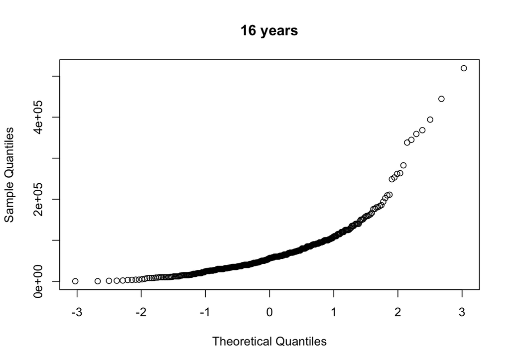

```r
qqnorm(edu16$Income2005, main= '16 years')
```

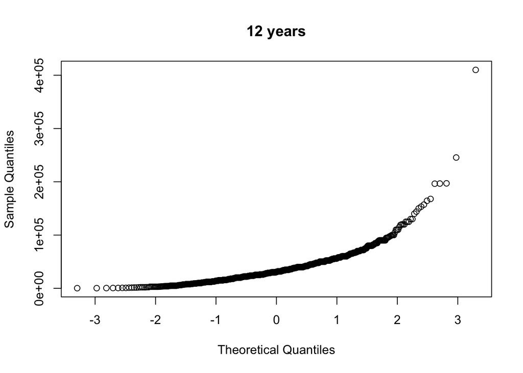

```r
qqnorm(edu12$Income2005, main= '12 years')
```

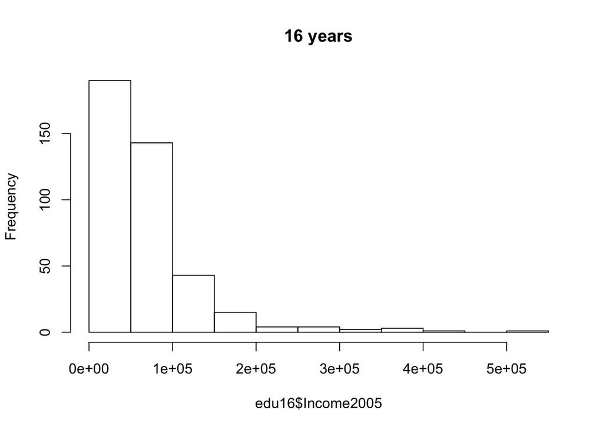

```r
hist(edu16$Income2005, main= '16 years')
```

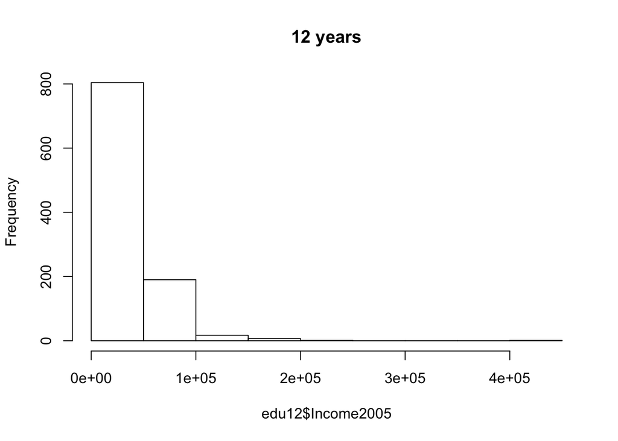

```r
hist(edu12$Income2005, main= '12 years')
```

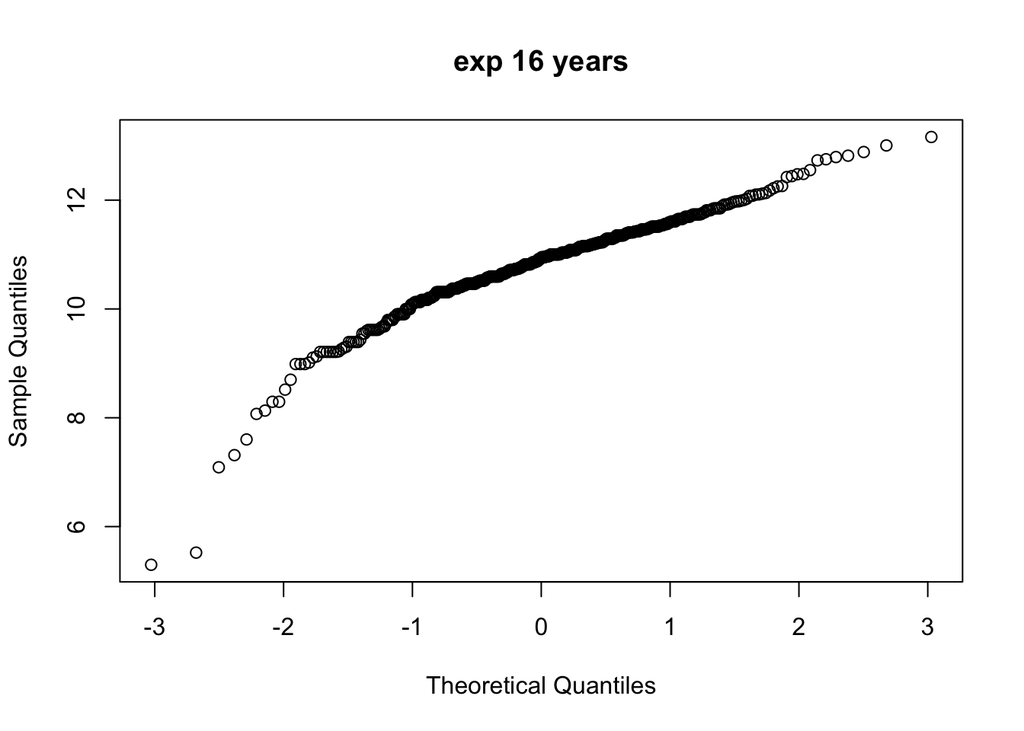

```r
edu16$logincome = log(edu16$Income2005)
edu12$logincome = log(edu12$Income2005)

qqnorm(edu16$logincome, main= 'exp 16 years')
```

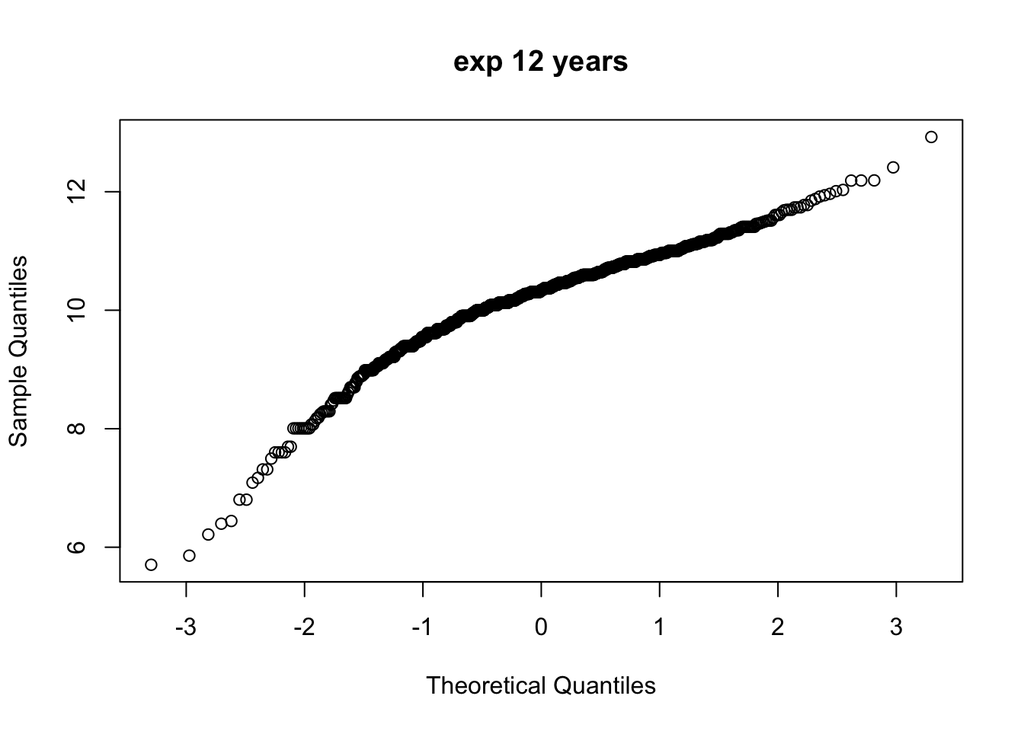

```r
qqnorm(edu12$logincome, main= 'exp 12 years')
```

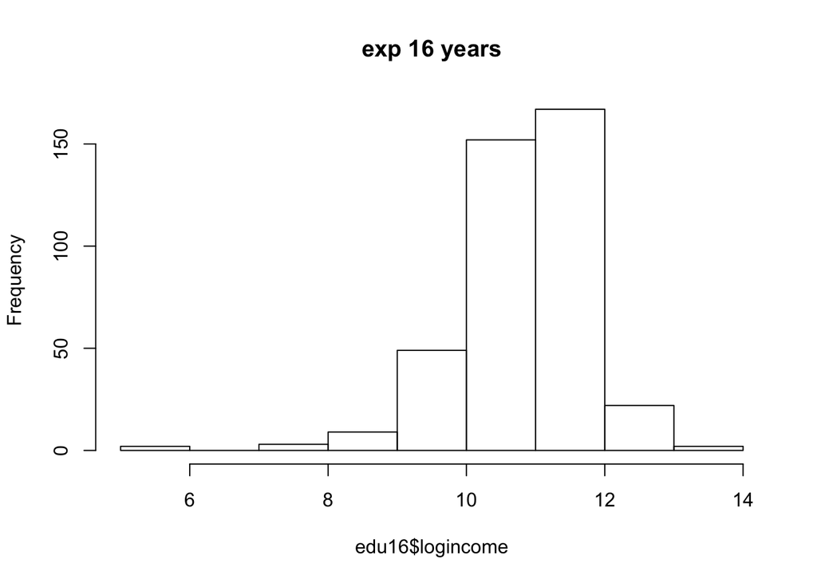

```r
hist(edu16$logincome, main= 'exp 16 years')
```

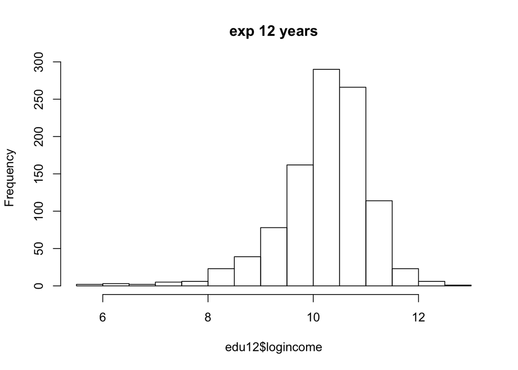

```r
hist(edu12$logincome, main= 'exp 12 years')
```

Finally, make sure you present your findings as you would to a client: **1**. State the Problem * Based on a study of the incomes of 1426 adults between the ages of 41 and 49 years old with educations between 12 and 16 years. We will test the null hypothesis that there is no diffirence between years of education and income levels later in life.

**2**. address the Assumptions (Graphically and using words). * There are 406 observations in the 16 years of eduacation group, and 1020 observations in the 12 years of education group. To ensure equal variance. The t-test will include a random sample of 406 observations from the 12 year education group. Additionally, the data set is not normally distributed. It appears to be exponentially distributed. To solve this we will be using the log transformation of the dataset; which is normally distributed.

**3**. Perform the Most Appropriate (Powerful) Test (in reality this may be a pooled t-test on the original data, a t-test on the log transformed data, or a permutation test on the original data since these are the ones we have studied so far. For now, assume you must choose between the pooled t-test on the original data or on the log transformed data.)

```r
edu12_sample = sample(edu12$logincome, 406)

t.test(edu16$logincome,
       edu12_sample,
       c('two.sided', 'less', 'greater'))
```

```
##
##  Welch Two Sample t-test
##
## data:  edu16$logincome and edu12_sample
## t = 9.0105, df = 776.13, p-value < 2.2e-16
## alternative hypothesis: true difference in means is not equal to 0
## 95 percent confidence interval:
##  0.4310250 0.6711446
## sample estimates:
## mean of x mean of y
##  10.79709  10.24600
```

```r
stdv = sd(c(edu16$logincome, edu12_sample))
ci = exp(c(0.4031292, 0.6490921))
print('mean pocket change')
```

```
## [1] "mean pocket change"
```

```r
exp(c(10.79709,  10.27098))
```

```
## [1] 48878.36 28882.18
```

```r
print('Confidence Interval')
```

```
## [1] "Confidence Interval"
```

```r
print(ci)
```

```
## [1] 1.496500 1.913802
```

**4**. Provide a conclusion including a p-value and a confidence interval.